# Project3

Alex Jones and Hudson Plaskoff

2026-05-01

# Introduction

For this project, we decided to examine potential relationships between the stock prices of companies with close ties to the US housing market and economic indicators based on trends in home construction and sales.

The companies we chose to look at are some of the largest publicly traded firms that are related to the housing market. They are listed below, along with their corresponding industry:[^1]

- HD - Home Depot (Home Improvement Retail)
- LOW - Lowe’s (Home Improvement Retail)
- DHI - D. R. Horton (Residential Construction)
- PHM - PulteGroup (Residential Construction)
- LEN - Lennar (Residential Construction)
- MAS - Masco (Building Products & Equipment)
- BLDR - Builders Firstsource (Building Products & Equipment)
- OC - Owens Corning (Building Products & Equipment)

We decided to only look at data from January 1, 2007 and later due to not all of our selected companies being publicly traded for much of the previous year. To do this, we used Python to import stock data for selected companies that are related to the US housing market. We also imported the following datasets from FRED (Federal Reserve Economic Data) from the Federal Reserve Bank of St. Louis:

- [Producer Price Index by Commodity: Special Indexes: Construction Materials](https://fred.stlouisfed.org/series/WPUSI012011)
  - Measures the relative cost of construction materials
- [Total Construction Spending: Residential in the United States](https://fred.stlouisfed.org/series/TLRESCONS)
  - Measures total construction spending (in millions of $) by companies that build residential buildings
- [New Privately-Owned Housing Units Started: Total Units](https://fred.stlouisfed.org/series/HOUST)
  - Measures the total number of new homes (in thousands) starting to be constructed
- [New One Family Houses Sold: United States](https://fred.stlouisfed.org/series/HSN1F)
  - Measures the total number of new one family homes sold (in thousands)

We don’t anticipate that we will use all of these datasets (stocks or economic data), but we believe that it would be beneficial to have them imported and ready to use in case we needed one of them that we hadn’t anticipated using.

Across all of the FRED datasets, the sample size is 228, which in this context of monthly observations means the data is from a 228 month (19 year) period of time. The sample size for the stock data across all of the stocks chosen is also 228, meaning it is also across 228 months (or 19 years) in the same period of time as the FRED data.

# Data Import

## Stock Data from Python (yfinance)

```python
import yfinance as yf
import pandas as pd

tickers = ["HD","LOW","DHI","PHM","LEN","MAS","BLDR","OC"]
start = "2007-01-01"
end = "2025-12-31"

stock_data = yf.download(tickers,start=start,end=end)
```

[output not shown]

```python
stock_close = stock_data["Close"]
```

```r
stock_close <- py$stock_close

stock_close <- stock_close %>%
  mutate(
    date = rownames(stock_close)
  ) %>%
  mutate(
    date = ymd_hms(date)
  ) %>%
  mutate(
     year = year(date),
     month = month(date),
     mday = day(date)
  )

stock_close_month <- stock_close %>%
  group_by(year,month) %>%
  summarize(
    HD = mean(HD),
    LOW = mean(LOW),
    DHI = mean(DHI),
    PHM = mean(PHM),
    LEN = mean(LEN),
    MAS = mean(MAS),
    BLDR = mean(BLDR),
    OC = mean(OC)
  ) %>%
  mutate(
    day = 1,
    .after = month
  ) %>%
  mutate(
    date = make_date(year,month,day),
    .before = year
  )

stock_close_month_pivoted <- stock_close_month %>%
  pivot_longer(
    cols = HD:OC,
    names_to = "stock",
    values_to = "price"
  )

knitr::kable(stock_close_month %>% head())
```

| date | year | month | day | HD | LOW | DHI | PHM | LEN | MAS | BLDR | OC |
| --- | --- | --- | --- | --- | --- | --- | --- | --- | --- | --- | --- |
| 2007-01-01 | 2007 | 1 | 1 | 24.68299 | 23.37028 | 21.12306 | 27.24821 | 39.72749 | 18.17778 | 14.66739 | 23.12713 |
| 2007-02-01 | 2007 | 2 | 1 | 25.14243 | 23.91047 | 21.87977 | 26.83038 | 40.71514 | 18.59314 | 15.67748 | 25.38792 |
| 2007-03-01 | 2007 | 3 | 1 | 23.40291 | 22.54805 | 18.22042 | 22.81712 | 35.43932 | 16.58338 | 14.41387 | 25.49823 |
| 2007-04-01 | 2007 | 4 | 1 | 23.72223 | 22.24777 | 17.42129 | 22.57954 | 33.01320 | 16.28417 | 14.12552 | 26.66170 |
| 2007-05-01 | 2007 | 5 | 1 | 23.90247 | 22.41345 | 17.94737 | 22.16025 | 34.34743 | 17.83118 | 13.69103 | 27.73850 |
| 2007-06-01 | 2007 | 6 | 1 | 23.98724 | 22.47433 | 16.75247 | 20.57657 | 31.93115 | 17.12878 | 13.79899 | 28.60417 |

We used the yfinance library in Python to easily access stock data from Yahoo Finance for our selected companies in the date range we indicated (January 2007 to December 2025). We then imported the created dataset into R and generated a mean closing price for each month, which was then assigned to be the first of each respective month so it could be more easily joined to datasets from FRED, which also assign the day as one for a given month’s data.

## Economic Data from FRED

```r
ppi_construction <- read_csv("WPUSI012011.csv") %>%
  rename(
    ppi_construction = WPUSI012011
  )

construction_spending <- read_csv("TLRESCONS.csv") %>%
  rename(
    construction_spending = TLRESCONS
  )

new_private_units <- read_csv("HOUST.csv") %>%
  rename(
    new_private_units = HOUST
  )

new_family_homes_sold <- read_csv("HSN1F.csv") %>%
  rename(
    new_family_homes_sold = HSN1F
  )

fred_data <- ppi_construction %>%
  left_join(construction_spending) %>%
  left_join(new_private_units) %>%
  left_join(new_family_homes_sold) %>%
  rename(
    date = observation_date
  )

fred_data_pivoted <- fred_data %>%
  pivot_longer(
    cols = ppi_construction:new_family_homes_sold,
    names_to = "economic_metric",
    values_to = "value"
  )

knitr::kable(fred_data %>% head())
```

| date | ppi_construction | construction_spending | new_private_units | new_family_homes_sold |
| --- | --- | --- | --- | --- |
| 2007-01-01 | 181.1 | 544096 | 1409 | 891 |
| 2007-02-01 | 181.5 | 538260 | 1480 | 828 |
| 2007-03-01 | 182.5 | 534655 | 1495 | 833 |
| 2007-04-01 | 183.7 | 530749 | 1490 | 887 |
| 2007-05-01 | 184.0 | 521499 | 1415 | 842 |
| 2007-06-01 | 184.0 | 513524 | 1448 | 793 |

The data import for the FRED data was simpler than the data import for the stocks. This was due largely to the option on the FRED website to download CSVs for each of the economic variables, which we then imported into R. This process was also helped by the date variable in each of these datasets being formatted as date data and also being set to the first of the month for each respective observation.

# Exploratory Data Analysis

## Stock Prices

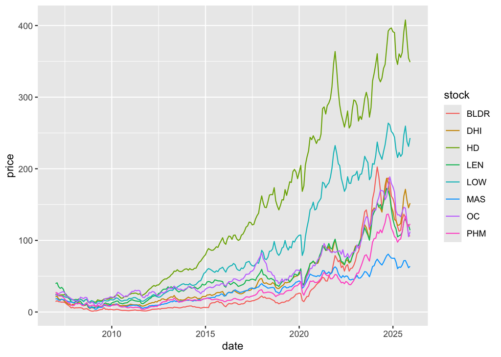

```r
ggplot(stock_close_month_pivoted,aes(x=date,y=price,color=stock)) +
  geom_line()
```

```r
stock_close_month_pivoted_data <- stock_close_month_pivoted %>%
  group_by(stock) %>%
  summarize(
    min_price = min(price),
    mean_price = mean(price),
    median_price = median(price),
    max_price = max(price),
  )

knitr::kable(stock_close_month_pivoted_data)
```

| stock | min_price | mean_price | median_price | max_price |
| --- | --- | --- | --- | --- |
| BLDR | 1.101346 | 35.42892 | 13.07095 | 202.51750 |
| DHI | 5.002927 | 47.31479 | 27.35712 | 186.80038 |
| HD | 13.606933 | 142.77021 | 102.92210 | 407.72162 |
| LEN | 5.327909 | 51.88619 | 40.42430 | 172.65448 |
| LOW | 11.932000 | 90.05258 | 61.28343 | 263.69778 |
| MAS | 3.764499 | 30.69839 | 27.28967 | 80.79326 |
| OC | 6.531154 | 56.58260 | 40.38724 | 188.70071 |
| PHM | 3.643579 | 33.58909 | 19.44434 | 136.73100 |

Since 2007, all of the stocks we chose have increased in price. Because this is data over a time period and not a more standard comparison of observations, the mean and median represent the average stock price from 2007 to the present rather than the average prices of different stocks in a given group. Something to note is that companies with very small low’s such as BLDR, DHI, LEN, MAS, OC, and PHM likely had stock splits after periods of growth, meaning that their stock price would have originally been the low price listed times whatever the ratio of the split was. In terms of the highest prices at the end of this period, Home Depot (HD) is the highest and Masco (MAS) is the lowest.

## Economic Data

### PPI (Construction Materials)

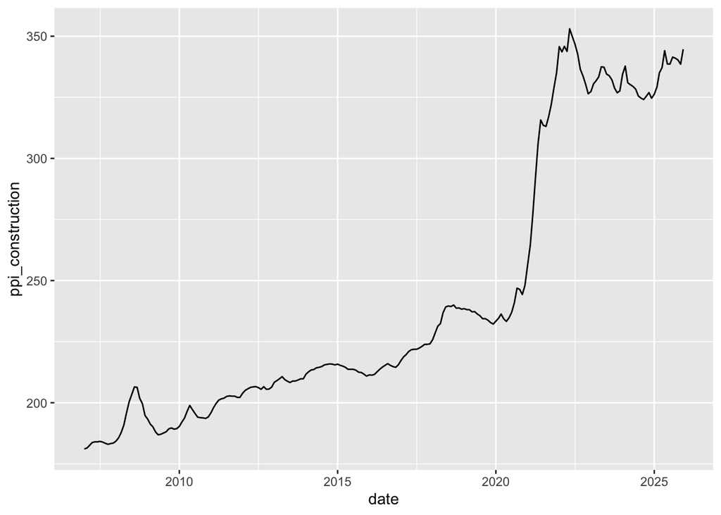

```r
ggplot(fred_data,aes(x=date,y=ppi_construction)) +
  geom_line()
```

```r
ppi_construction_data <- fred_data %>%
  summarize(
    min_ppi = min(ppi_construction),
    mean_ppi = mean(ppi_construction),
    median_ppi = median(ppi_construction),
    max_ppi = max(ppi_construction),
  )

knitr::kable(ppi_construction_data)
```

| min_ppi | mean_ppi | median_ppi | max_ppi |
| --- | --- | --- | --- |
| 181.1 | 241.9401 | 215.5 | 353.015 |

The PPI of construction materials shows a sharp increase in late 2020 and early 2021, which is roughly the same time when inflation in the US began to spike in the initial aftermath of the COVID-19 pandemic. While it didn’t continue to increase, it has remained at a higher baseline level since this initial rise

### Residential Construction Spending

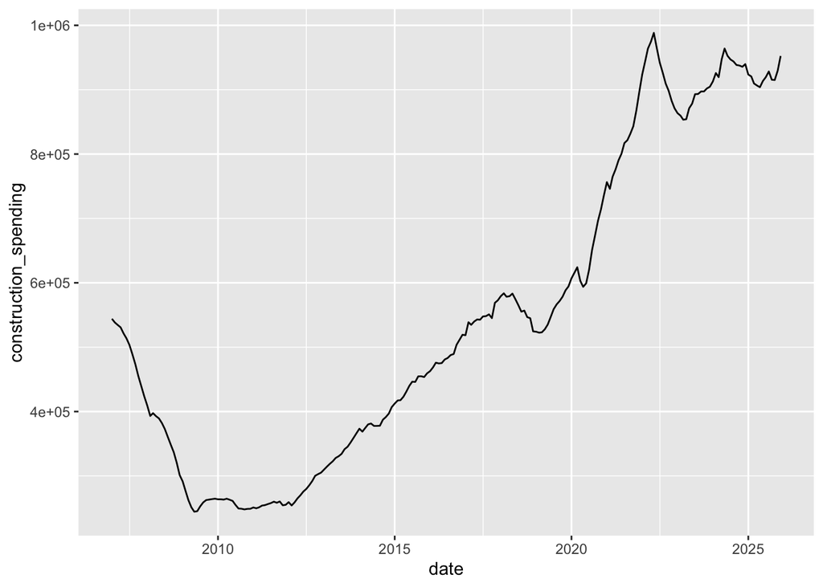

```r
ggplot(fred_data,aes(x=date,y=construction_spending)) +
  geom_line()
```

```r
construction_spending_data <- fred_data %>%
  summarize(
    min_spending = min(construction_spending),
    mean_spending = mean(construction_spending),
    median_spending = median(construction_spending),
    max_spending = max(construction_spending),
  )

knitr::kable(construction_spending_data)
```

| min_spending | mean_spending | median_spending | max_spending |
| --- | --- | --- | --- |
| 244399 | 544587.4 | 516063.5 | 988269 |

Similarly to the PPI of construction materials, the level of residential construction spending increased in the same time. This is not because of inflation, but instead because of low interest rates which allowed construction companies to borrow at a more affordable rate, in turn leading to higher profitability on construction projects. These low interest rates also contributed to the inflation discussed above with PPI for construction materials.

### New Private Housing Units

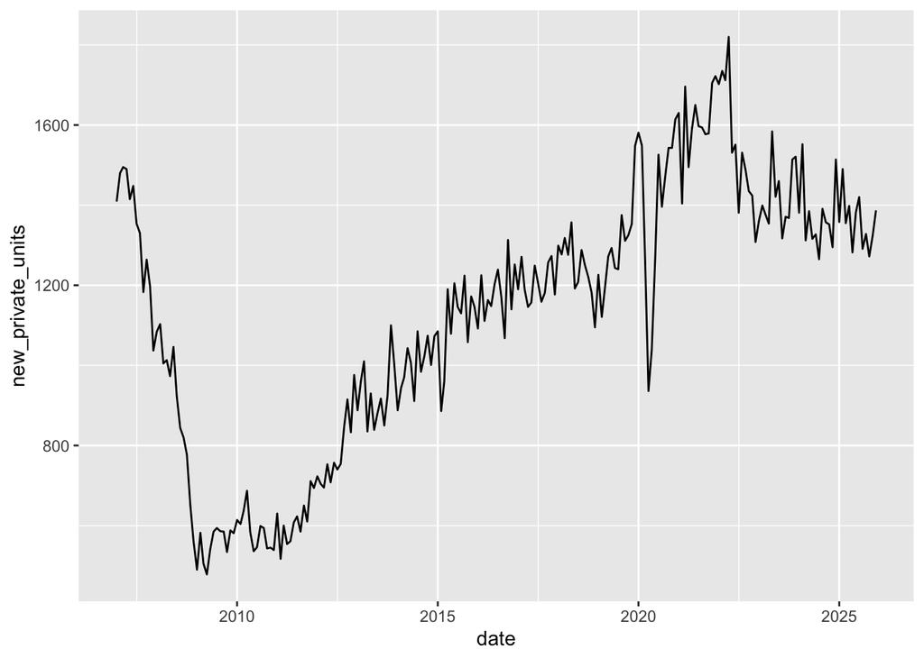

```r
ggplot(fred_data,aes(x=date,y=new_private_units)) +
  geom_line()
```

```r
new_private_units_data <- fred_data %>%
  summarize(
    min_new_units = min(new_private_units),
    mean_new_units = mean(new_private_units),
    median_new_units = median(new_private_units),
    max_new_units = max(new_private_units),
  )

knitr::kable(new_private_units_data)
```

| min_new_units | mean_new_units | median_new_units | max_new_units |
| --- | --- | --- | --- |
| 478 | 1127.877 | 1190 | 1820 |

The sharp decrease in new homes being built in early 2020 was likely due to the fear of decreased imports of construction materials in the first few months of the COVID-19 pandemic. However, the increase immediately thereafter was likely due to these fears being offset by the aforementioned lower interest rates, which then allowed for the number of new homes being built to increase past pre-COVID levels until early 2023. Notably, the sharp decrease in 2007 and 2008 (in both this and in residential construction spending) is almost certainly related to the collapse of the housing bubble in these years and the subsequent recession.

### New One Family Homes Sold

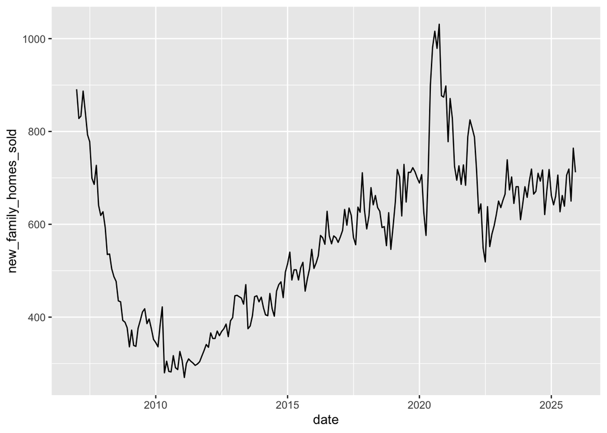

```r
ggplot(fred_data,aes(x=date,y=new_family_homes_sold)) +
  geom_line()
```

```r
new_family_homes_sold_data <- fred_data %>%
  summarize(
    min_new_sold = min(new_family_homes_sold),
    mean_new_sold = mean(new_family_homes_sold),
    median_new_sold = median(new_family_homes_sold),
    max_new_sold = max(new_family_homes_sold),
  )

knitr::kable(new_family_homes_sold_data)
```

| min_new_sold | mean_new_sold | median_new_sold | max_new_sold |
| --- | --- | --- | --- |
| 270 | 564.8684 | 577.5 | 1031 |

# Research

## Research Question

The question we decided to examine is this:

To what extent does there exist a correlation between various economic metrics and publicly traded equities related to the US housing market?

```r
joined_stock_economic_data <- fred_data %>%
  left_join(stock_close_month) %>%
  select(
    !(year:day)
  )

knitr::kable(joined_stock_economic_data %>% head())
```

| date | ppi_construction | construction_spending | new_private_units | new_family_homes_sold | HD | LOW | DHI | PHM | LEN | MAS | BLDR | OC |
| --- | --- | --- | --- | --- | --- | --- | --- | --- | --- | --- | --- | --- |
| 2007-01-01 | 181.1 | 544096 | 1409 | 891 | 24.68299 | 23.37028 | 21.12306 | 27.24821 | 39.72749 | 18.17778 | 14.66739 | 23.12713 |
| 2007-02-01 | 181.5 | 538260 | 1480 | 828 | 25.14243 | 23.91047 | 21.87977 | 26.83038 | 40.71514 | 18.59314 | 15.67748 | 25.38792 |
| 2007-03-01 | 182.5 | 534655 | 1495 | 833 | 23.40291 | 22.54805 | 18.22042 | 22.81712 | 35.43932 | 16.58338 | 14.41387 | 25.49823 |
| 2007-04-01 | 183.7 | 530749 | 1490 | 887 | 23.72223 | 22.24777 | 17.42129 | 22.57954 | 33.01320 | 16.28417 | 14.12552 | 26.66170 |
| 2007-05-01 | 184.0 | 521499 | 1415 | 842 | 23.90247 | 22.41345 | 17.94737 | 22.16025 | 34.34743 | 17.83118 | 13.69103 | 27.73850 |
| 2007-06-01 | 184.0 | 513524 | 1448 | 793 | 23.98724 | 22.47433 | 16.75247 | 20.57657 | 31.93115 | 17.12878 | 13.79899 | 28.60417 |

```r
joined_stock_economic_data_pivoted <- joined_stock_economic_data %>%
  pivot_longer(
    cols = ppi_construction:OC,
    names_to = "metric",
    values_to = "value"
  ) %>%
  mutate(
    type = case_when(
      metric == "ppi_construction" | metric == "construction_spending" | metric == "new_private_units" | metric == "new_family_homes_sold" ~ "economy",
      .default = "stock"
    )
  )
```

## D. R. Horton and Producer Price Index of Construction Materials

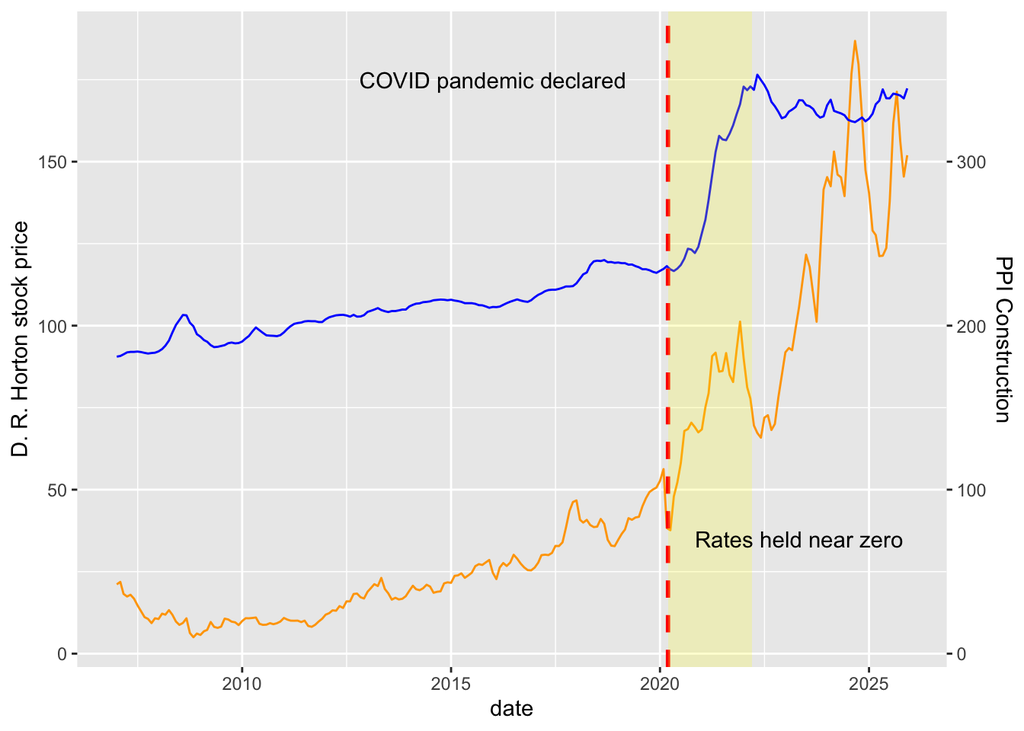

```r
coeff <- 2

ggplot(joined_stock_economic_data,aes(x=date)) +
  geom_line(aes(y=DHI),color="orange") +
  geom_line(aes(y=ppi_construction/coeff),color="blue") +
  scale_y_continuous(
    # First Axis
    name = "D. R. Horton stock price",
    # Second Axis
    sec.axis = sec_axis(~.*coeff, name="PPI Construction")
  ) +
  geom_vline(xintercept = as.numeric(as.Date("2020-03-11")), color = "red", linetype = "dashed", size = 1) +
  annotate("rect",
           xmin = as.Date("2020-03-16"),
           xmax = as.Date("2022-03-16"),
           ymin = -Inf, ymax = Inf,
           alpha = 0.2, fill = "yellow") +
  annotate("text", x=as.Date("2016-01-01"), y=175, label= "COVID pandemic declared") +
  annotate("text", x=as.Date("2023-05-01"), y=35, label= "Rates held near zero")
```

```r
stocks_by_ppi <- joined_stock_economic_data %>%
  summarize(
    HD_cor = cor(HD,ppi_construction),
    LOW_cor = cor(LOW,ppi_construction),
    DHI_cor = cor(DHI,ppi_construction),
    PHM_cor = cor(PHM,ppi_construction),
    LEN_cor = cor(LEN,ppi_construction),
    MAS_cor = cor(MAS,ppi_construction),
    BLDR_cor = cor(BLDR,ppi_construction),
    OC_cor = cor(OC,ppi_construction)
  )

knitr::kable(stocks_by_ppi)
```

| HD_cor | LOW_cor | DHI_cor | PHM_cor | LEN_cor | MAS_cor | BLDR_cor | OC_cor |
| --- | --- | --- | --- | --- | --- | --- | --- |
| 0.9477616 | 0.9667283 | 0.9111846 | 0.8469972 | 0.8997142 | 0.9041302 | 0.8652752 | 0.8877377 |

All of the stocks chosen have a strong positive correlation with the PPI of construction materials, meaning the value of these companies increased as the PPI of construction materials also increased. Of the companies, the strongest correlations were with Home Depot and Lowe’s, both of which are home improvement retail companies. However, these correlations being stronger than those of other companies are relative, as all of the stocks chosen still had very high correlations.

D. R. Horton was chosen in this graph to show similar points between a stock’s price and an economic metric. Both show an increase in early 2021 as rates remained low, but they diverge in 2023 as rates were raised. After this point in 2023, the PPI of construction materials have remained relatively flat but still elevated, while D. R. Horton’s stock has continued to increase.

## Home Depot and Residential Construction Spending

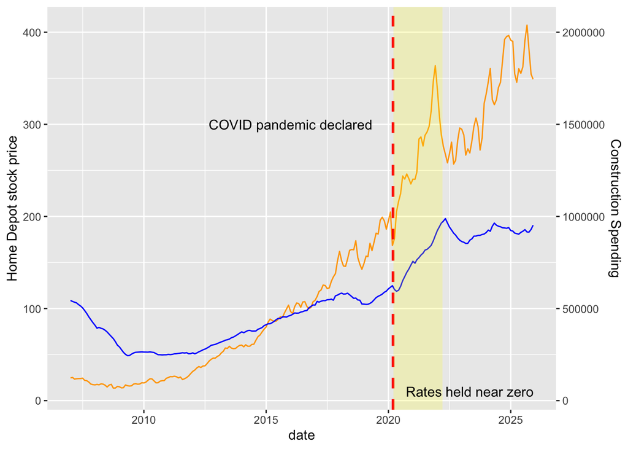

```r
coeff3 <- 5000

ggplot(joined_stock_economic_data,aes(x=date)) +
  geom_line(aes(y=HD),color="orange") +
  geom_line(aes(y=construction_spending/coeff3),color="blue") +
  scale_y_continuous(
    # First Axis
    name = "Home Depot stock price",
    # Second Axis
    sec.axis = sec_axis(~.*coeff3, name="Construction Spending")
  ) +
  geom_vline(xintercept = as.numeric(as.Date("2020-03-11")), color = "red", linetype = "dashed", size = 1) +
  annotate("rect",
           xmin = as.Date("2020-03-16"),
           xmax = as.Date("2022-03-16"),
           ymin = -Inf, ymax = Inf,
           alpha = 0.2, fill = "yellow") +
  annotate("text", x=as.Date("2016-01-01"), y=300, label= "COVID pandemic declared") +
  annotate("text", x=as.Date("2023-05-01"), y=10, label= "Rates held near zero")
```

```r
stocks_by_construction <- joined_stock_economic_data %>%
  summarize(
    HD_cor = cor(HD,construction_spending),
    LOW_cor = cor(LOW,construction_spending),
    DHI_cor = cor(DHI,construction_spending),
    PHM_cor = cor(PHM,construction_spending),
    LEN_cor = cor(LEN,construction_spending),
    MAS_cor = cor(MAS,construction_spending),
    BLDR_cor = cor(BLDR,construction_spending),
    OC_cor = cor(OC,construction_spending)
  )

knitr::kable(stocks_by_construction)
```

| HD_cor | LOW_cor | DHI_cor | PHM_cor | LEN_cor | MAS_cor | BLDR_cor | OC_cor |
| --- | --- | --- | --- | --- | --- | --- | --- |
| 0.9544739 | 0.9603113 | 0.9057922 | 0.8515588 | 0.9121748 | 0.9561327 | 0.8439307 | 0.8870503 |

All of the stocks chosen have a very positive correlation with the amount of residential construction spending, meaning the value of these companies increased as the level of residential construction spending in the US increased. Of the companies, the strongest correlations were with Home Depot, Lowe’s, and Masco, but again these correlations being stronger than others are only in relative terms, as all of the stocks chosen still had very high correlations.

Home Depot was chosen for this graph to show similar changes for a stock price and an economic metric. In a very similar way to D.R. Horton and the PPI of construction materials above, the graph of Home Depot and the level of residential construction spending follows similar trends, with increases in both values in 2021 as inflation increased and rates remained low, followed by continued rise in a stock price afterward and the level of construction spending remaining flat at the same time.

## Masco and New Private Housing Units Started

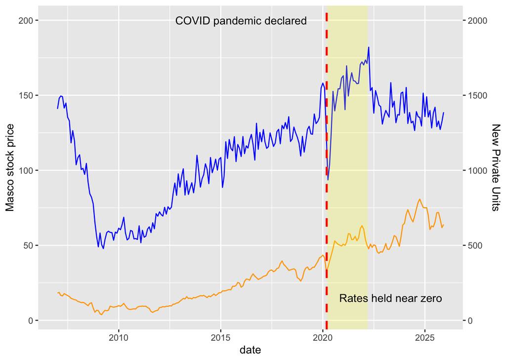

```r
coeff2 <- 10

ggplot(joined_stock_economic_data,aes(x=date)) +
  geom_line(aes(y=MAS),color="orange") +
  geom_line(aes(y=new_private_units/coeff2),color="blue") +
  scale_y_continuous(
    # First Axis
    name = "Masco stock price",
    # Second Axis
    sec.axis = sec_axis(~.*coeff2, name="New Private Units")
  ) +
  geom_vline(xintercept = as.numeric(as.Date("2020-03-11")), color = "red", linetype = "dashed", size = 1) +
  annotate("rect",
           xmin = as.Date("2020-03-16"),
           xmax = as.Date("2022-03-16"),
           ymin = -Inf, ymax = Inf,
           alpha = 0.2, fill = "yellow") +
  annotate("text", x=as.Date("2016-01-01"), y=200, label= "COVID pandemic declared") +
  annotate("text", x=as.Date("2023-05-01"), y=15, label= "Rates held near zero")
```

```r
stocks_by_new_units <- joined_stock_economic_data %>%
  summarize(
    HD_cor = cor(HD,new_private_units),
    LOW_cor = cor(LOW,new_private_units),
    DHI_cor = cor(DHI,new_private_units),
    PHM_cor = cor(PHM,new_private_units),
    LEN_cor = cor(LEN,new_private_units),
    MAS_cor = cor(MAS,new_private_units),
    BLDR_cor = cor(BLDR,new_private_units),
    OC_cor = cor(OC,new_private_units)
  )

knitr::kable(stocks_by_new_units)
```

| HD_cor | LOW_cor | DHI_cor | PHM_cor | LEN_cor | MAS_cor | BLDR_cor | OC_cor |
| --- | --- | --- | --- | --- | --- | --- | --- |
| 0.7591778 | 0.7416802 | 0.6468844 | 0.5825645 | 0.6969635 | 0.7953776 | 0.5441034 | 0.6287622 |

While all of the chosen stocks do have a positive correlation with the number of new private housing units that began construction, they are not as strong as the correlations observed previously with both the PPI of construction materials and construction spending. Despite mostly following the same trends in the COVID-19 pandemic and afterward, what appears to differentiate this metric from those observed previously is a much sharper decline during the 2007-2008 financial crisis that it only recovered from directly before the pandemic.

## Lowe’s and New One Family Homes Sold

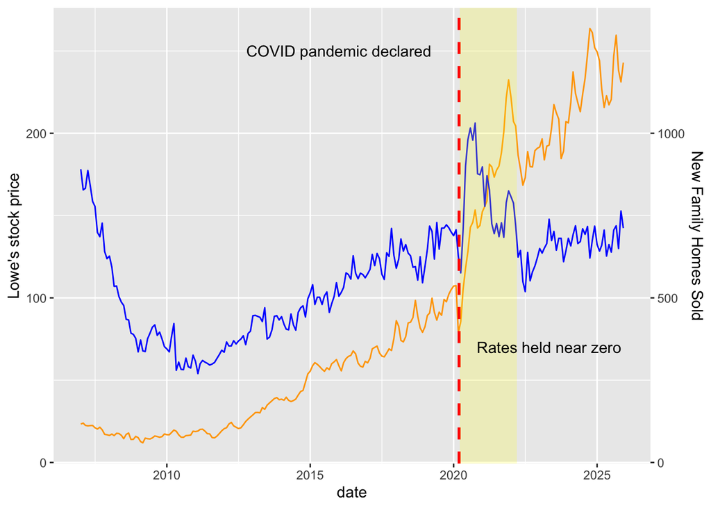

```r
coeff2 <- 5

ggplot(joined_stock_economic_data,aes(x=date)) +
  geom_line(aes(y=LOW),color="orange") +
  geom_line(aes(y=new_family_homes_sold/coeff2),color="blue") +
  scale_y_continuous(
    # First Axis
    name = "Lowe's stock price",
    # Second Axis
    sec.axis = sec_axis(~.*coeff2, name="New Family Homes Sold")
  ) +
  geom_vline(xintercept = as.numeric(as.Date("2020-03-11")), color = "red", linetype = "dashed", size = 1) +
  annotate("rect",
           xmin = as.Date("2020-03-16"),
           xmax = as.Date("2022-03-16"),
           ymin = -Inf, ymax = Inf,
           alpha = 0.2, fill = "yellow") +
  annotate("text", x=as.Date("2016-01-01"), y=250, label= "COVID pandemic declared") +
  annotate("text", x=as.Date("2023-05-01"), y=70, label= "Rates held near zero")
```

```r
stocks_by_new_homes <- joined_stock_economic_data %>%
  summarize(
    HD_cor = cor(HD,new_family_homes_sold),
    LOW_cor = cor(LOW,new_family_homes_sold),
    DHI_cor = cor(DHI,new_family_homes_sold),
    PHM_cor = cor(PHM,new_family_homes_sold),
    LEN_cor = cor(LEN,new_family_homes_sold),
    MAS_cor = cor(MAS,new_family_homes_sold),
    BLDR_cor = cor(BLDR,new_family_homes_sold),
    OC_cor = cor(OC,new_family_homes_sold)
  )

knitr::kable(stocks_by_new_homes)
```

| HD_cor | LOW_cor | DHI_cor | PHM_cor | LEN_cor | MAS_cor | BLDR_cor | OC_cor |
| --- | --- | --- | --- | --- | --- | --- | --- |
| 0.6588864 | 0.632733 | 0.5735623 | 0.5341533 | 0.6005302 | 0.7202095 | 0.4566098 | 0.5265948 |

Similar to the metric of new homes that started construction, the number of new homes sold also had a much sharper decrease relative to PPI of construction materials and construction spending, meaning it also has a lower, although still positive, correlation with all of the chosen stocks. However, the chosen stock of Lowe’s did also mirror some key moments that reoccurred in other metrics, such as volatility after the beginning of the COVID-19 pandemic and a decrease during 2008.

# Conclusion

According to our analysis of these four economic metrics against our selected stocks, we observed a higher positive correlation between these stocks and the metrics of PPI of construction materials and the amount of residential spending than the correlation with the other metrics of new housing units started and new homes sold. One reason for this is because metrics such as PPI specifically generally only increase over time, as prices of materials typically are only pushed upwards, whereas metrics such as homes that have began construction or homes that have been sold typically wax and wane between a given range over time rather than simply increasing or decreasing.

[^1]: According to [Finviz](https://finviz.com/)